# Plots related to Bryant *et al* 2021b

Astra S. Bryant, PhD

May 07, 2021

# 1 Introduction/Abstract

This purpose of this document is to collect, analyze, and plot data associated with the mansucript titled "Neural Mechanisms of Thermosensation in the Human Parasite *Strongyloides stercoralis*.

The data analyzed here belong to two different classes of experiments: thermotaxis tracking assays, and thermosensory calcium imaging experiments.

## 1.1 Setup

# 2 *Ss-Tax-4* and *strHisCl1* Experiments

These data show the results of the following experimental questions:

- Role of *Ss-tax-4* in negative thermotaxis behaviors by *S. stercoralis* iL3s
- Effect of chemogenetic inactivation of *Ss*-AFD on positive thermotaxis
- Effect of chemogenetic inactivation of *Ss*-AFD on negative thermotaxis

## 2.1 Data Inputs

These data were calculated by the TT_WormTracker Matlab code and are imported into RStudio from the results document generated by Matlab.

- Change in temperature ($^\circ$C)
- Worm speed (mm/s)
- Distance ratio (total distance traveled/max displacement)

```r
dat_inactivation_file <- c('~/Box Sync/Lab_Hallem/Astra/Writing/Bryant et al 20xx/Data/Tax4HisCl1_R_Import.xlsx')

if (is_empty(dat_inactivation_file)){
  dat_inactivation_file <- file.choose()
}
dat_inactivation <- read_excel(dat_inactivation_file, sheet = 1) %>%
  group_by(Experiment,ThermoMode, Phenotype) %>%
  dplyr::mutate(Experiment = factor(Experiment, levels = c("HisCl", "CRISPR"))) %>%
  dplyr::mutate(ThermoMode = factor(ThermoMode, levels = c("PT", "NT"))) %>%
  dplyr::mutate(Phenotype = factor(Phenotype, levels = c("BU", "Histamine", "NoCas9", "Ss-tax-4")))
```

## 2.2 Plot Templates

```r
plot_tracking <-  function(dat, y, ylim, xlabel, ylabel, title = NULL, groupcolors,groupshapes){
  ggplot(data = dat, mapping = aes(x = Phenotype, y = y)) +
    stat_boxplot(geom = "errorbar",
                 width = 0.25,
                 size = .5) +
    geom_boxplot(width = 0.5,
                 outlier.shape = NA,
                 fatten = 1,
                 key_glyph = "rect",
                 alpha = 0.3,
                 show.legend = F,
                 aes(fill = Phenotype)) +
    geom_jitter(size = 1,
                stroke = .75,
                width = .2,
                aes(color = Phenotype, shape = Experiment)) +
    scale_y_continuous(limits = ylim,
                       expand = expansion(add = 0)) +
    scale_color_manual(values = groupcolors,
                       aesthetics = c("colour", "fill")) +
    scale_shape_manual(values = groupshapes)  +
    xlab(xlabel) +
    ylab(ylabel) +
    ggtitle(title) +
    theme_Publication() +
    theme(aspect.ratio = 2/1,
          axis.text.x = element_text(angle= 45,
                                     hjust = 1))
}
```

## 2.3 *Ss*-AFD chemogenetic silencing

Worm: *Sr-gcy-23.2p::strHisCl1* iL3s, with and without treatment with exogenous histamine

### 2.3.1 Positive Thermotaxis

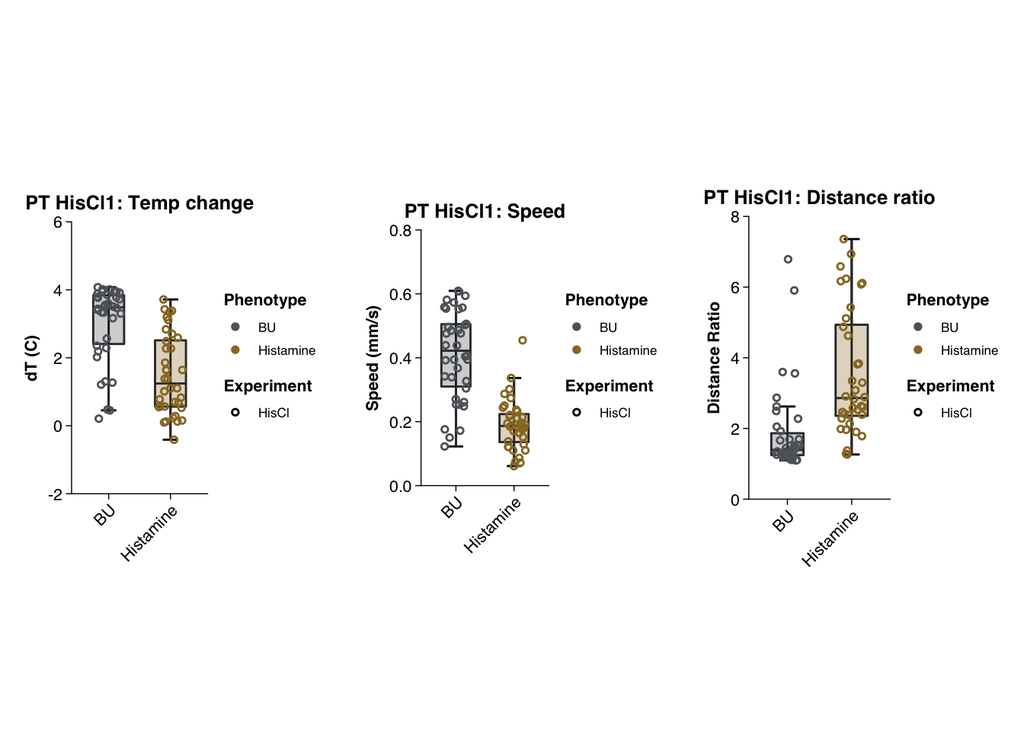

```r
p.PT.HisCl.dT<- dat_inactivation %>%
  dplyr::filter(Experiment == "HisCl") %>%
  dplyr::filter(ThermoMode == "PT") %>%
  plot_tracking(dat = .,
                y = .$dT,
                ylim = c(-2,6),
                xlabel = NULL,
                ylabel = "dT (C)",
                title = "PT HisCl1: Temp change",
                groupcolors = c("BU" = "#5F6369",
                                "Histamine" = "#99772C"),
                groupshapes = 21)

p.PT.HisCl.Speed<- dat_inactivation %>%
  dplyr::filter(Experiment == "HisCl") %>%
  dplyr::filter(ThermoMode == "PT") %>%
  plot_tracking(dat = .,
                y = .$Speed,
                ylim = c(0,0.8),
                xlabel = NULL,
                title = "PT HisCl1: Speed",
                ylabel = "Speed (mm/s)",
                groupcolors = c("BU" = "#5F6369",
                                "Histamine" = "#99772C"),
                groupshapes = 21)

p.PT.HisCl.DR<- dat_inactivation %>%
  dplyr::filter(Experiment == "HisCl") %>%
  dplyr::filter(ThermoMode == "PT") %>%
  plot_tracking(dat = .,
                y = .$`Distance Ratio`,
                ylim = c(0,8),
                xlabel = NULL,
                title = "PT HisCl1: Distance ratio",
                ylabel = "Distance Ratio",
                groupcolors = c("BU" = "#5F6369",
                                "Histamine" = "#99772C"),
                groupshapes = 21)

ggarrange(
  p.PT.HisCl.dT,
  p.PT.HisCl.Speed,
  p.PT.HisCl.DR,
  ncol = 3,
  nrow = 1
)
```

### 2.3.2 Negative Thermotaxis

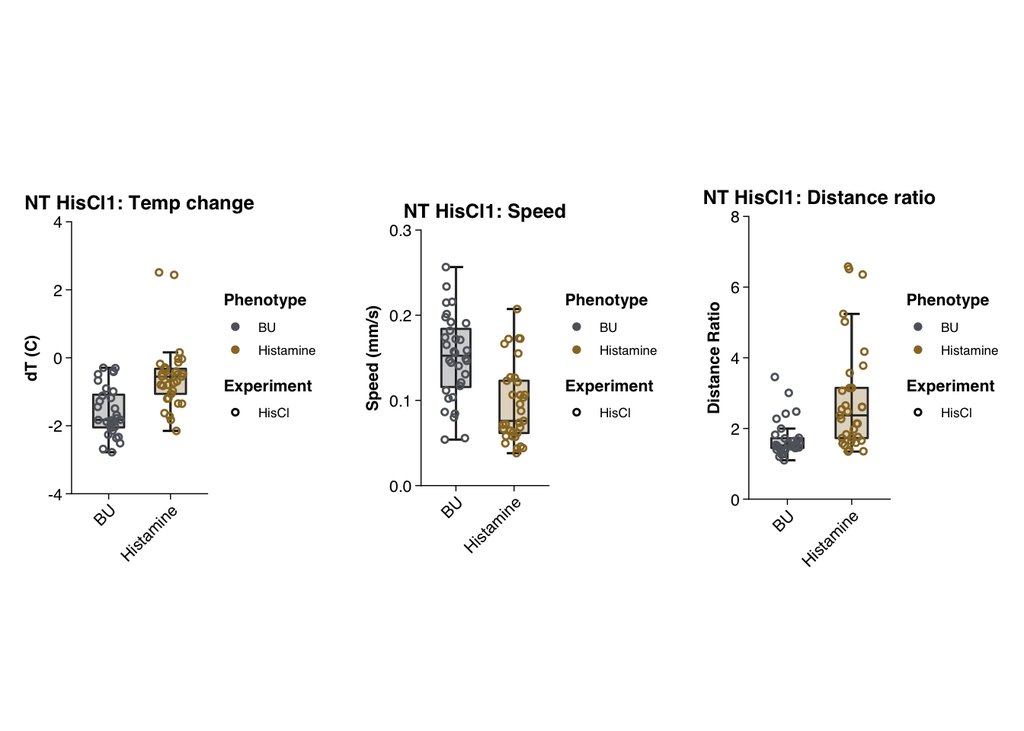

```r
p.NT.HisCl.dT<- dat_inactivation %>%
  dplyr::filter(Experiment == "HisCl") %>%
  dplyr::filter(ThermoMode == "NT") %>%
  plot_tracking(dat = .,
                y = .$dT,
                ylim = c(-4,4),
                xlabel = NULL,
                ylabel = "dT (C)",
                title = "NT HisCl1: Temp change",
                groupcolors = c("BU" = "#5F6369",
                                "Histamine" = "#99772C"),
                groupshapes = 21)

p.NT.HisCl.Speed<- dat_inactivation %>%
  dplyr::filter(Experiment == "HisCl") %>%
  dplyr::filter(ThermoMode == "NT") %>%
  plot_tracking(dat = .,
                y = .$Speed,
                ylim = c(0,0.3001),
                xlabel = NULL,
                ylabel = "Speed (mm/s)",
                title = "NT HisCl1: Speed",
                groupcolors = c("BU" = "#5F6369",
                                "Histamine" = "#99772C"),
                groupshapes = 21)

p.NT.HisCl.DR<- dat_inactivation %>%
  dplyr::filter(Experiment == "HisCl") %>%
  dplyr::filter(ThermoMode == "NT") %>%
  plot_tracking(dat = .,
                y = .$`Distance Ratio`,
                ylim = c(0,8),
                xlabel = NULL,
                ylabel = "Distance Ratio",
                title = "NT HisCl1: Distance ratio",
                groupcolors = c("BU" = "#5F6369",
                                "Histamine" = "#99772C"),
                groupshapes = 21)

ggarrange(
  p.NT.HisCl.dT,
  p.NT.HisCl.Speed,
  p.NT.HisCl.DR,
  ncol = 3,
  nrow = 1
)
```

## 2.4 *Ss-tax-4* CRISPR/Cas9 KO

CRISPR/Cas9-mediated targeted mutagensis of the *Ss-tax-4* gene. Control worms were not injected with Cas9 plasmid vectors.

### 2.4.1 Negative Thermotaxis

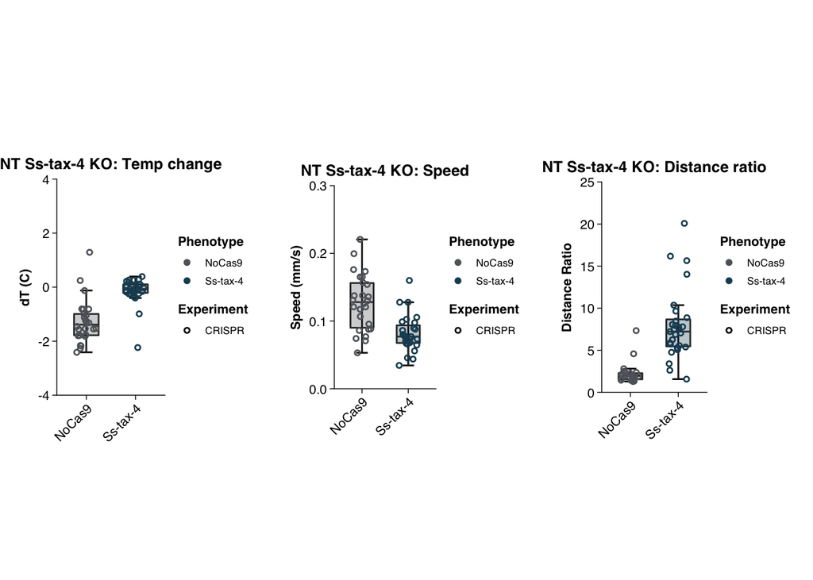

```r
p.NT.CRISPR.dT<- dat_inactivation %>%
  dplyr::filter(Experiment == "CRISPR") %>%
  dplyr::filter(ThermoMode == "NT") %>%
  plot_tracking(dat = .,
                y = .$dT,
                ylim = c(-4,4),
                xlabel = NULL,
                ylabel = "dT (C)",
                title = "NT Ss-tax-4 KO: Temp change",
                groupcolors = c("NoCas9" = "#5F6369",
                                "Ss-tax-4" = "#1A4C62"),
                groupshapes = 21)

p.NT.CRISPR.Speed<- dat_inactivation %>%
  dplyr::filter(Experiment == "CRISPR") %>%
  dplyr::filter(ThermoMode == "NT") %>%
  plot_tracking(dat = .,
                y = .$Speed,
                ylim = c(0,0.3001),
                xlabel = NULL,
                ylabel = "Speed (mm/s)",
                title = "NT Ss-tax-4 KO: Speed",
                groupcolors = c("NoCas9" = "#5F6369",
                                "Ss-tax-4" = "#1A4C62"),
                groupshapes = 21)

p.NT.CRISPR.DR<- dat_inactivation %>%
  dplyr::filter(Experiment == "CRISPR") %>%
  dplyr::filter(ThermoMode == "NT") %>%
  plot_tracking(dat = .,
                y = .$`Distance Ratio`,
                ylim = c(0,25),
                xlabel = NULL,
                ylabel = "Distance Ratio",
                title = "NT Ss-tax-4 KO: Distance ratio",
                groupcolors = c("NoCas9" = "#5F6369",
                                "Ss-tax-4" = "#1A4C62"),
                groupshapes = 21)

ggarrange(
  p.NT.CRISPR.dT,
  p.NT.CRISPR.Speed,
  p.NT.CRISPR.DR,
  ncol = 3,
  nrow = 1
)
```

### 2.4.2 Group and Save Plots

```r
ggarrange(
  p.PT.HisCl.dT,
  p.PT.HisCl.Speed,
  p.PT.HisCl.DR,
  p.NT.CRISPR.dT,
  p.NT.CRISPR.Speed,
  p.NT.CRISPR.DR,
  p.NT.HisCl.dT,
  p.NT.HisCl.Speed,
  p.NT.HisCl.DR,
  ncol = 3,
  nrow = 3
) %>%
  ggsave(filename ="HisClTax4_Plots.pdf",
         device = cairo_pdf,
         width = 10.5,
         height = 6.3,
         path = dirname(dat_inactivation_file))
```

# 3 AFD Response Properties

Thermosensory response properties of *C. elegans* AFD (strain = IK890), and *S. stercoralis* AFD (expression plasmid = pASB52).

The data reflect the responses of *C. elegans* AFD and *S. stercoralis* AFD to the following thermal stimuli:

- Pseudo-fictive PT 20-34$^\circ$C ramp
- Pseudo-fictive PTe 20-40$^\circ$C ramp
- Pseudo-fictive PT15 12-26$^\circ$C ramp
- Pseudo-fictive PT15e 12-32$^\circ$C ramp
- Non-physiological PT 17-40$^\circ$C ramp
- Non-physiological NT 20-12$^\circ$C ramp

## 3.1 Data Inputs

These data were preprocessed and calculated by TCI Matlab code.

```r
dat_AFD_file <- c('~/Box Sync/Lab_Hallem/Astra/Writing/Bryant et al 20xx/Data/Calcium Imaging/AFDResponse_R_Import.xlsx')

if (is_empty(dat_AFD_file)){
  dat_AFD_file <- file.choose()
}
dat_AFD <- read_excel(dat_AFD_file, sheet = 1) %>%
  group_by(Species,Tc, Stimulus) %>%
  dplyr::mutate(Species = as_factor(Species)) %>%
  dplyr::mutate(Stimulus = factor(Stimulus, levels = c("pFPT", "pFPTe", "R4", "NT"))) %>%
  dplyr::mutate(Tc = factor(Tc, levels = c(23, 15)))

dat_AFD_15 <- dplyr::filter(dat_AFD, Tc == 15) %>%
  dplyr::filter(Stimulus != "R4") %>%
  dplyr::filter(Stimulus != "NT")

dat_AFD_23 <- dplyr::filter(dat_AFD, Tc == 23) %>%
  dplyr::filter(Stimulus != "R4") %>%
  dplyr::filter(Stimulus != "NT")

dat_AFD_allTc <- dat_AFD %>%
  dplyr::filter(Stimulus != "R4") %>%
  dplyr::filter(Stimulus != "NT")

dat_AFD_R4 <- dat_AFD %>%
  dplyr::filter(Stimulus == "R4")

dat_AFD_across <- dplyr::filter(dat_AFD, Tc == 23)  %>%
  dplyr::filter(Stimulus != "NT") %>%
  dplyr::mutate(Type = as_factor(case_when(
    Stimulus == "R4" ~ "Fast",
    Stimulus != "R4" ~ "Slow")))
```

## 3.2 Slow “Fictive” Stimuli

Responses of *Ss*-AFD and *Ce*-AFD to thermal stimuli based on the temperatures experienced by *S. stercoralis* iL3s performing postitive thermotaxis in a 20-34C temperature gradient. In these cases, ramp speeds are generally 0.025C/s.

### 3.2.1 Plot Templates

```r
plot_AFD <- function(dat, y, ylim, xlabel, ylabel, stat.test, stat.y.position, title = NULL){
  ggplot(data = dat, mapping = aes(x = Species, y = y)) +
    stat_boxplot(geom = "errorbar",
                 width = 0.25,
                 size = .5) +
    geom_boxplot(width = 0.5,
                 outlier.shape = NA,
                 fatten = 1,
                 key_glyph = "rect",
                 alpha = 0.3,
                 show.legend = F,
                 aes(fill = Species)) +
    geom_jitter(size = 1,
                stroke = .75,
                width = .2,
                aes(color = Species, shape = Stimulus)) +
    stat_pvalue_manual(stat.test,
                       y.position = stat.y.position,
                       tip.length = 0,
                       bracket.shorten = 0.2,
                       label = 'p.signif') +
    scale_y_continuous(limits = ylim,
                       expand = expansion(add = 0)) +
    scale_color_carto_d(palette = "Vivid") +
    scale_fill_carto_d(palette = "Vivid") +
    scale_shape_manual(values = c(21:23))  +
    xlab(xlabel) +
    ylab(ylabel) +
    ggtitle(title) +
    theme_Publication() +
    theme(aspect.ratio = 2/1)
}


plot_AFD_Speciesfacet <- function(dat, y, ylim, xlabel, ylabel, title = NULL){
  ggplot(data = dat, mapping = aes(x = Tc, y = y)) +
    stat_boxplot(geom = "errorbar",
                 width = 0.25,
                 size = .5) +
    geom_boxplot(width = 0.5,
                 outlier.shape = NA,
                 fatten = 1,
                 key_glyph = "rect",
                 alpha = 0.3,
                 show.legend = F,
                 aes(fill = Species)) +
    geom_jitter(size = 1,
                stroke = .75,
                width = .2,
                aes(color = Species, shape = Stimulus)) +
    # stat_pvalue_manual(stat.test,
    #                    y.position = stat.y.position,
    #                    label = 'p.signif') +
    facet_grid(. ~ Species)+
    scale_y_continuous(limits = ylim,
                       expand = expansion(add = 0)) +
    scale_color_carto_d(palette = "Vivid") +
    scale_fill_carto_d(palette = "Vivid") +
    scale_shape_manual(values = c(21:23))  +
    xlab(xlabel) +
    ylab(ylabel) +
    ggtitle(title) +
    theme_Publication() +
    theme(aspect.ratio = 2/1)
}
```

### 3.2.2 Temperature Threshold

The temperature threshold for each worm. Threshold is defined as the temperature at which point the caclium response deviates from baseline (F0) response by at least 3 * STD of baseline, for the duration of time it takes for the stimulus ramp to advance 0.25C. For the slow temperature ramps (.025C/s) plotted here, this time is therefore 10 seconds.

Baseline (F0) responses are defined as the calcium responses at the followin temperatures:

- For Tc = 23, F0 = 20C
- For Tc = 15, F0 = 12C

Statistics are the results of Wilcoxon signed-rank tests.

#### 3.2.2.1 Tc = 23C

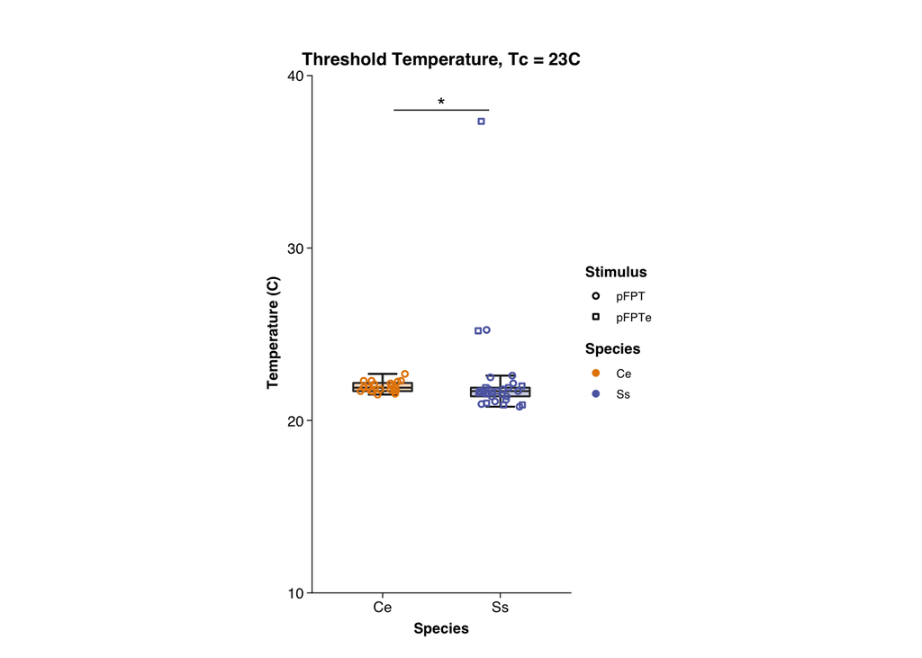

```r
xlabel <- "Species"
ylabel <- " Temperature (C)"
title <- "Threshold Temperature, Tc = 23C"
ylim <- c(10, 40)

stat.thresh.23 <- compare_means(Temperature ~ Species,
                                data = dat_AFD_23,
                                alternative = "two.sided")

p.thresh.23 <- plot_AFD(dat_AFD_23,
                        dat_AFD_23$Temperature,
                        ylim,
                        xlabel,
                        ylabel,
                        stat.thresh.23,
                        38,
                        title)

print(p.thresh.23)
```

#### 3.2.2.2 Tc = 15C

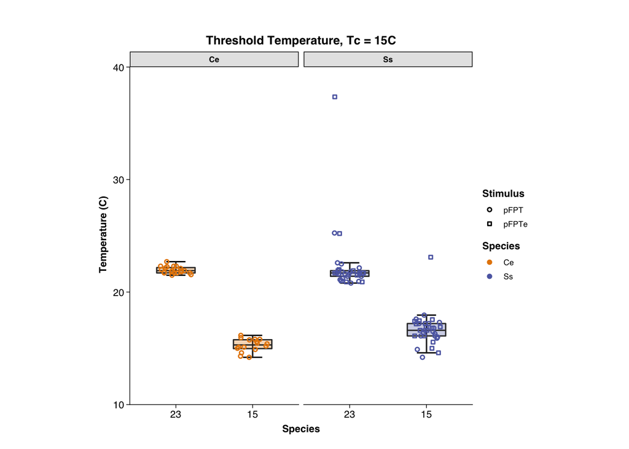

```r
xlabel <- "Species"
ylabel <- " Temperature (C)"
title <- "Threshold Temperature, Tc = 15C"
ylim <- c(10, 40)


p.thresh.allTc <- plot_AFD_Speciesfacet(dat_AFD_allTc,
                                        dat_AFD_allTc$Temperature,
                                        ylim,
                                        xlabel,
                                        ylabel,
                                        title)

print(p.thresh.allTc)
```

### 3.2.3 Pearson Correlation

Is the calcium response above threshold linearly correlated with changes in temperature. Correlation between calcium repsonses and temperature are analyzed across the following temperature ranges:

- For Tc = 23, from 25 - 34C (pF PT) or 25 - 40C (pF PTe)
- For Tc = 15, from 17 - 26C (pF PT15) or 17 - 32C (pF PT15e)

#### 3.2.3.1 Tc = 23C

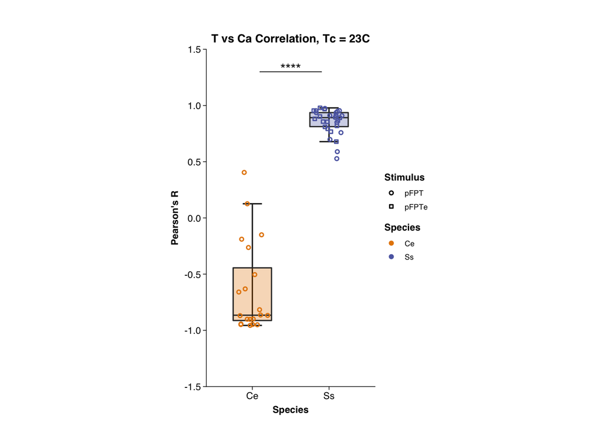

```r
ylabel <- "Pearson's R"
title <- "T vs Ca Correlation, Tc = 23C"
ylim <- c(-1.5, 1.5)
stat.pearson.23 <- compare_means(AboveThPearsonR ~ Species,
                                 data = dat_AFD_23,
                                 alternative = "two.sided")

p.pearson.23 <- plot_AFD(dat_AFD_23,
                         dat_AFD_23$AboveThPearsonR,
                         ylim,
                         xlabel,
                         ylabel,
                         stat.pearson.23,
                         1.3,
                         title)

print(p.pearson.23)
```

#### 3.2.3.2 Tc = 15C

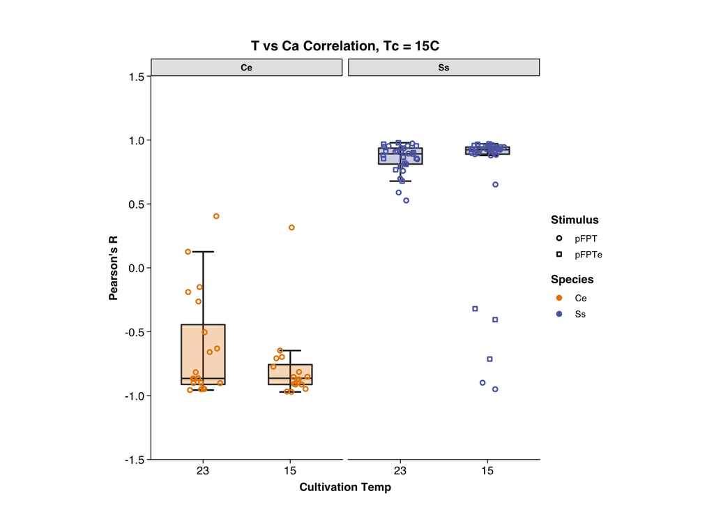

```r
ylabel <- "Pearson's R"
title <- "T vs Ca Correlation, Tc = 15C"
ylim <- c(-1.5, 1.5)
xlabel <- "Cultivation Temp"

p.pearson.allTc <- plot_AFD_Speciesfacet(dat_AFD_allTc,
                                         dat_AFD_allTc$AboveThPearsonR,
                                         ylim,
                                         xlabel,
                                         ylabel,
                                         title)

print(p.pearson.allTc)
```

### 3.2.4 Spearman Correlation

Is the calcium response near threshold linearly correlated with changes in temperature. Correlation between calcium repsonses and temperature are analyzed across the following temperature ranges:

- For Tc = 23, from 20 - 25C
- For Tc = 15, from 12 - 17C

#### 3.2.4.1 Tc = 23C

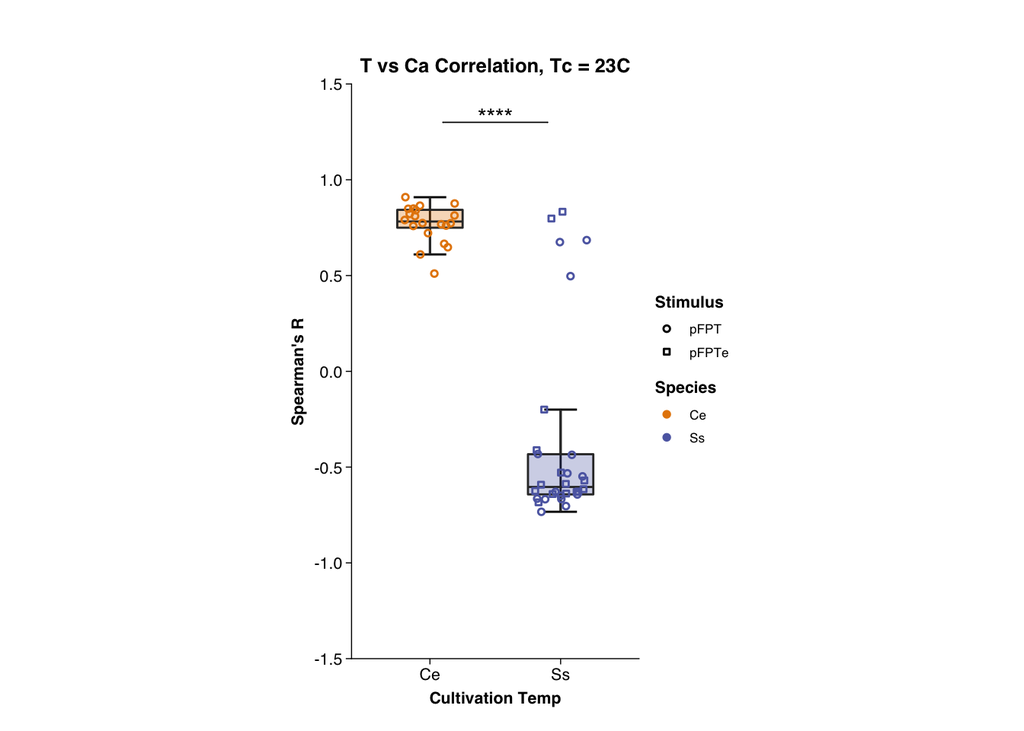

```r
ylabel <- "Spearman's R"
title <- "T vs Ca Correlation, Tc = 23C"
ylim <- c(-1.5, 1.5)
stat.spearman.23 <- compare_means(AtThSpearmanR ~ Species,
                                  data = dat_AFD_23,
                                  alternative = "two.sided")

p.spearman.23 <- plot_AFD(dat_AFD_23,
                          dat_AFD_23$AtThSpearmanR,
                          ylim,
                          xlabel,
                          ylabel,
                          stat.spearman.23,
                          1.3,
                          title)

print(p.spearman.23)
```

#### 3.2.4.2 Tc = 15C

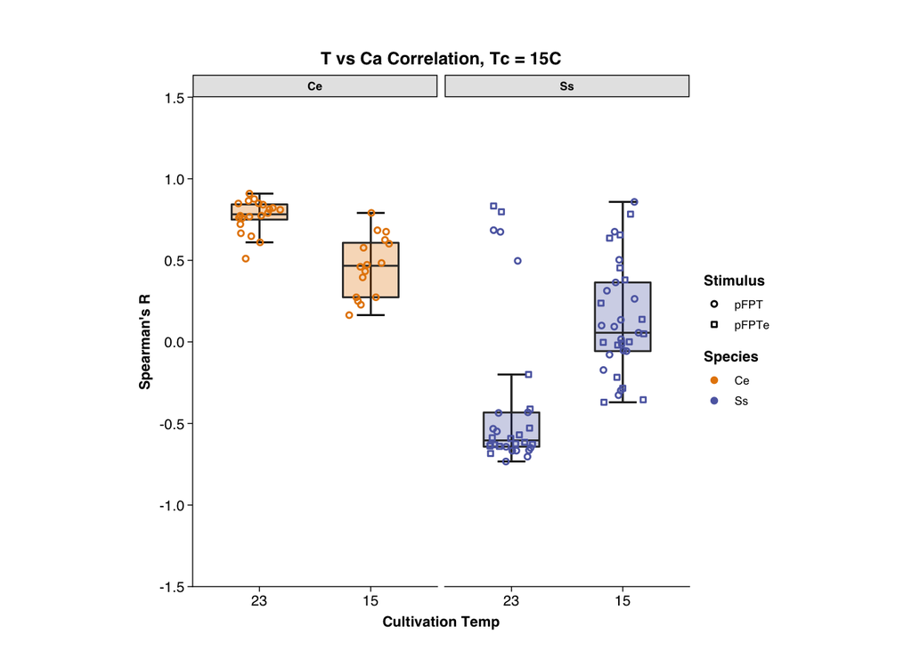

```r
ylabel <- "Spearman's R"
title <- "T vs Ca Correlation, Tc = 15C"
ylim <- c(-1.5, 1.5)
xlabel <- "Cultivation Temp"

p.spearman.allTc <- plot_AFD_Speciesfacet(dat_AFD_allTc,
                                          dat_AFD_allTc$AtThSpearmanR,
                                          ylim,
                                          xlabel,
                                          ylabel,
                                          title)

print(p.spearman.allTc)
```

### 3.2.5 Temperature eliciting maximal and minimal calcium response

Plots showing the temperature that corresponds to the maximum and minimal calcium response for each trace.

#### 3.2.5.1 Max Response

Only use values from traces from the pF PT stimulus, not the extended versions.

##### 3.2.5.1.1 Tc = 23C

```r
ylabel <- "Temperature (C)"
title <- "Temp @ Max Response, Tc = 23C"
ylim <- c(15, 40)

temp_dat <- dplyr::filter(dat_AFD_23, Stimulus == "pFPT")

stat.max.23 <- compare_means(MaximalTemp ~ Species,
                             data = temp_dat,
                             alternative = "two.sided")
```

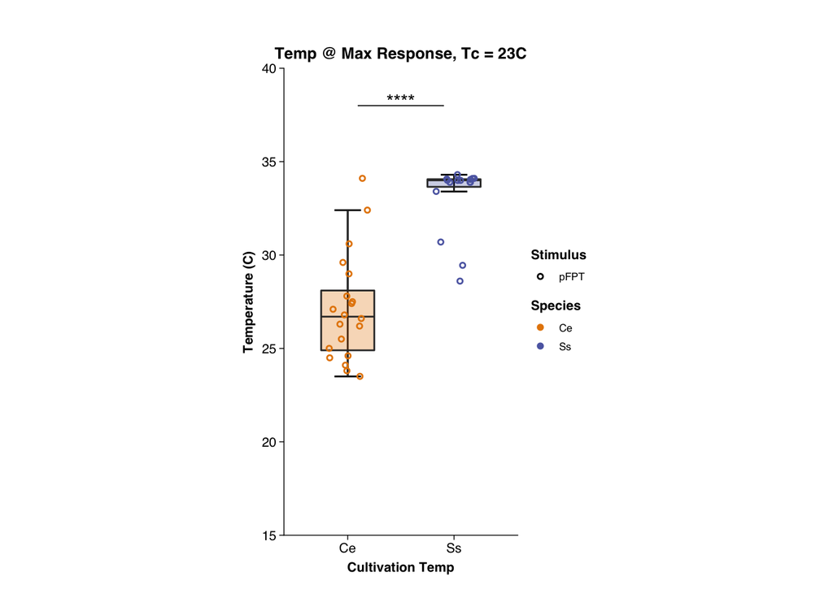

```r
p.max.23 <- plot_AFD(temp_dat,
                     temp_dat$MaximalTemp,
                     ylim,
                     xlabel,
                     ylabel,
                     stat.max.23,
                     38,
                     title)

print(p.max.23)
```

##### 3.2.5.1.2 Tc = 15C

```r
ylabel <- "Temperature (C)"
title <- "Temp @ Max Response, Tc = 15C"
ylim <- c(10, 35)

temp_dat <- dplyr::filter(dat_AFD_15, Stimulus == "pFPT")

stat.max.15 <- compare_means(MaximalTemp ~ Species,
                             data = temp_dat,
                             alternative = "two.sided")
```

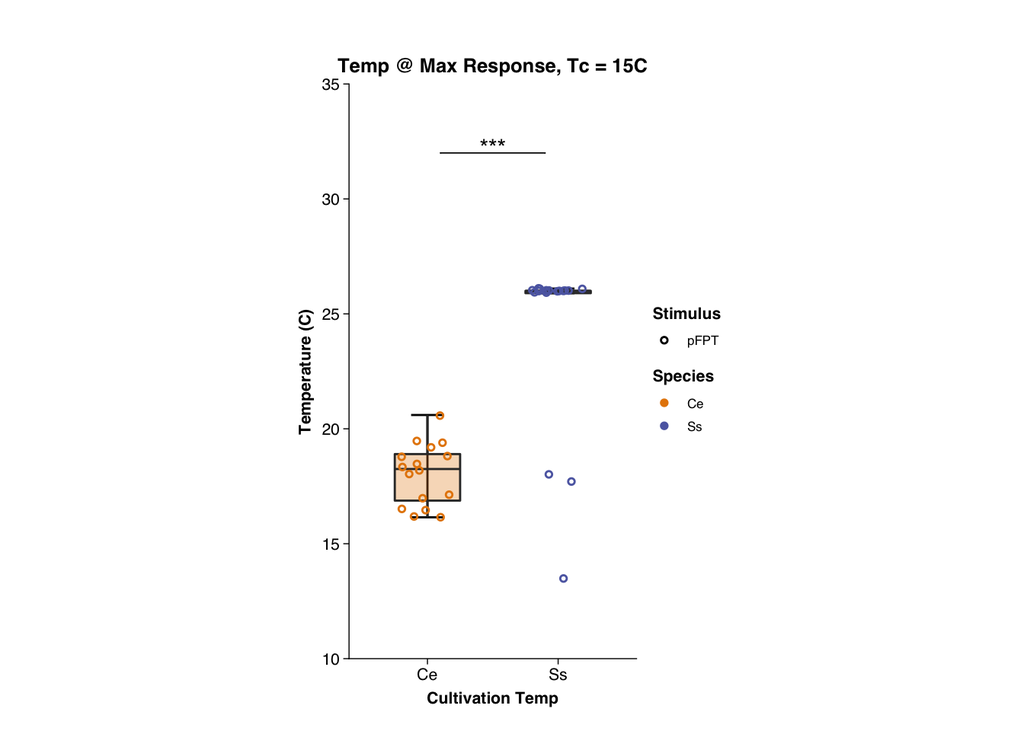

```r
p.max.15 <- plot_AFD(temp_dat,
                     temp_dat$MaximalTemp,
                     ylim,
                     xlabel,
                     ylabel,
                     stat.max.15,
                     32,
                     title)

print(p.max.15)
```

#### 3.2.5.2 Min Response

##### 3.2.5.2.1 Tc = 23C

```r
ylabel <- "Temperature (C)"
title <- "Temp @ Min Response, Tc = 23C"
ylim <- c(15, 40)

stat.min.23 <- compare_means(MinimalTemperature ~ Species,
                             data = dat_AFD_23,
                             alternative = "two.sided")
```

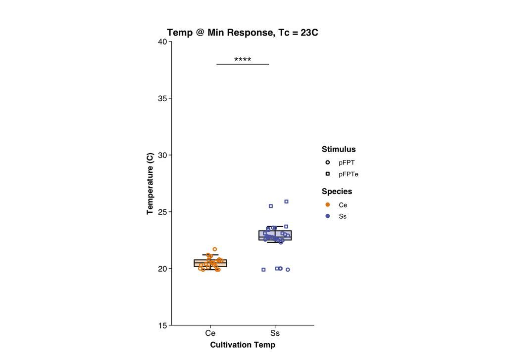

```r
p.min.23 <- plot_AFD(dat_AFD_23,
                     dat_AFD_23$MinimalTemperature,
                     ylim,
                     xlabel,
                     ylabel,
                     stat.min.23,
                     38,
                     title)

print(p.min.23)
```

##### 3.2.5.2.2 Tc = 15C

```r
ylabel <- "Temperature (C)"
title <- "Temp @ Min Response, Tc = 15C"
ylim <- c(10, 35)

stat.min.15 <- compare_means(MinimalTemperature ~ Species,
                             data = dat_AFD_15,
                             alternative = "two.sided")
```

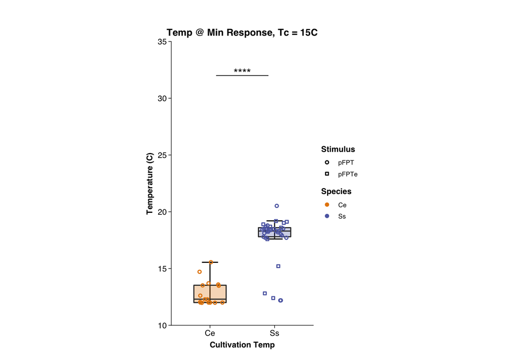

```r
p.min.15 <- plot_AFD(dat_AFD_15,
                     dat_AFD_15$MinimalTemperature,
                     ylim,
                     xlabel,
                     ylabel,
                     stat.min.15,
                     32,
                     title)

print(p.min.15)
```

### 3.2.6 Group and Save AFD Plots

```r
ggarrange(
  p.thresh.23,
  p.thresh.allTc,
  p.min.23,
  p.max.23,
  p.min.15,
  p.max.15,
  p.pearson.23,
  p.spearman.23,
  ncol = 2,
  nrow = 4
) %>%
  ggsave(filename ="AFD_Plots_pF.pdf",
         device = cairo_pdf,
         width = 7,
         height = 8.4,
         path = dirname(dat_AFD_file))
```

## 3.3 Fast Stimuli

Responses of *Ss*-AFD and *Ce*-AFD to thermal ramps based on those commonly used for *C. elegans* experiments (Colon-Ramos lab, in particular). In these cases, ramp speeds are generally 0.1C/s.

### 3.3.1 Plot Templates

```r
source("theme_Publication.R")
plot_AFD <- function(dat, y, ylim, xlabel, ylabel, stat.test, stat.y.position, title = NULL){
  ggplot(data = dat, mapping = aes(x = Species, y = y)) +
    stat_boxplot(geom = "errorbar",
                 width = 0.25,
                 size = .5) +
    geom_boxplot(width = 0.5,
                 outlier.shape = NA,
                 fatten = 1,
                 key_glyph = "rect",
                 alpha = 0.3,
                 show.legend = F,
                 aes(fill = Species)) +
    geom_jitter(size = 1,
                stroke = .75,
                width = .2,
                aes(color = Species, shape = Stimulus)) +
    stat_pvalue_manual(stat.test,
                       y.position = stat.y.position,
                       tip.length = 0,
                       bracket.shorten = 0.2,
                       label = 'p.signif') +
    scale_y_continuous(limits = ylim,
                       expand = expansion(add = 0)) +
    scale_color_carto_d(palette = "Vivid") +
    scale_fill_carto_d(palette = "Vivid") +
    scale_shape_manual(values = c(23))  +
    xlab(xlabel) +
    ylab(ylabel) +
    ggtitle(title) +
    theme_Publication() +
    theme(aspect.ratio = 2/1)
}

plot_AFD_type <- function(dat, y, ylim, xlabel, ylabel, title = NULL){
  ggplot(data = dat, mapping = aes(x = Type, y = y)) +
    stat_boxplot(geom = "errorbar",
                 width = 0.25,
                 size = .5) +
    geom_boxplot(width = 0.5,
                 outlier.shape = NA,
                 fatten = 1,
                 key_glyph = "rect",
                 alpha = 0.3,
                 show.legend = F,
                 aes(fill = Species)) +
    geom_jitter(size = 1,
                stroke = .75,
                width = .2,
                aes(color = Species, shape = Stimulus)) +
    facet_grid(. ~ Species)+
    scale_y_continuous(limits = ylim,
                       expand = expansion(add = 0)) +
    scale_color_carto_d(palette = "Vivid") +
    scale_fill_carto_d(palette = "Vivid") +
    scale_shape_manual(values = c(21:23))  +
    xlab(xlabel) +
    ylab(ylabel) +
    ggtitle(title) +
    theme_Publication() +
    theme(aspect.ratio = 2/1)
}
```

### 3.3.2 Pearson Correlation

Is the calcium response linearly correlated with changes in temperature. Correlation between calcium repsonses and temperature are analyzed across the following temperature ranges:

- For Tc = 23, from 25 - 40C (R4)

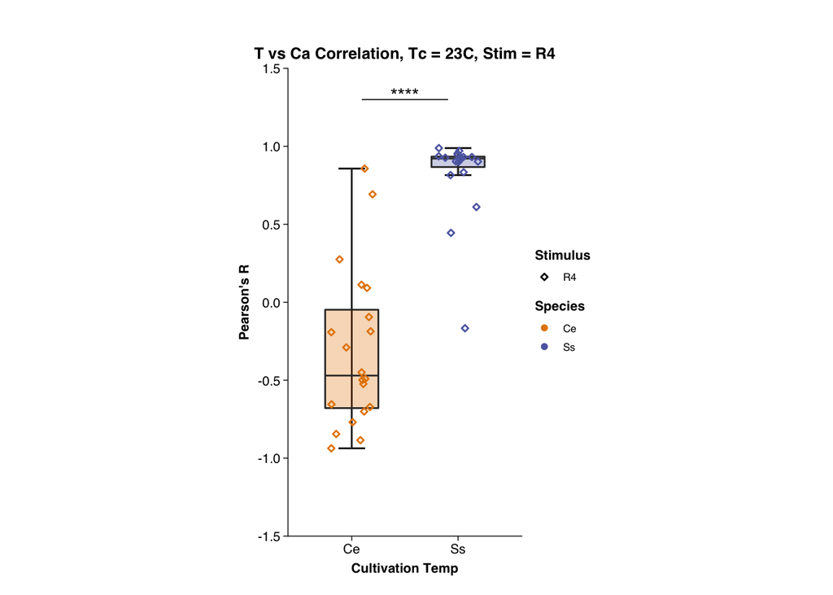

```r
ylabel <- "Pearson's R"
title <- "T vs Ca Correlation, Tc = 23C, Stim = R4"
ylim <- c(-1.5, 1.5)
stat.pearson.R4 <- compare_means(AboveThPearsonR ~ Species,
                                 data = dat_AFD_R4,
                                 alternative = "two.sided")

p.pearson.R4 <- plot_AFD(dat_AFD_R4,
                         dat_AFD_R4$AboveThPearsonR,
                         ylim,
                         xlabel,
                         ylabel,
                         stat.pearson.R4,
                         1.3,
                         title)

print(p.pearson.R4)
```

### 3.3.3 Temperature Threshold

The temperature threshold for each worm. Threshold is defined as the temperature at which point the caclium response deviates from baseline (F0) response by at least 3 * STD of baseline, for the duration of time it takes for the stimulus ramp to advance 0.25C. For the fast temperature ramps (.1C/s) plotted here, this time is therefore 2.5 seconds.

Baseline (F0) responses are defined as the calcium responses at the followin temperatures:

- For Tc = 23, F0 = 17C

Statistics are the results of Wilcoxon signed-rank tests.

```r
xlabel <- "Species"
ylabel <- " Temperature (C)"
title <- "Threshold Temperature, Tc = 23C, Stim = R4"
ylim <- c(10, 40)

options(contrasts = c("contr.sum", "contr.poly"))
res.aov2<- aov(Temperature ~ Type * Species, data = dat_AFD_across)
Anova(res.aov2, type = "III")
```

|  | Sum Sq | Df | F value | Pr(>F) |
| --- | --- | --- | --- | --- |
| (Intercept) | 4.064417e+04 | 1 | 9.592287e+03 | 3.496229e-89 |
| Type | 1.477630e+01 | 1 | 3.487303e+00 | 6.528791e-02 |
| Species | 1.726254e-01 | 1 | 4.074071e-02 | 8.405215e-01 |
| Type:Species | 5.120639e+00 | 1 | 1.208504e+00 | 2.747325e-01 |
| Residuals | 3.601596e+02 | 85 | NA | NA |

```r
res.aov3<-TukeyHSD(res.aov2, "Type:Species")
as_tibble(res.aov3$`Type:Species`, rownames = "comparison") %>%
  separate(col = comparison, into = c("comp1", "LS1", "comp2", "LS2")) %>%
  dplyr::filter(LS1 == LS2) %>%
  unite(temp1, comp1, LS1, sep = ":")%>%
  unite(temp2, comp2, LS2, sep = ":")%>%
  unite(comparison, temp1, temp2, sep = "-")
```

| comparison | diff | lwr | upr | p adj |
| --- | --- | --- | --- | --- |
| Fast:Ce-Slow:Ce | -0.3409167 | -2.046753 | 1.3649193 | 0.9531420 |
| Fast:Ss-Slow:Ss | -1.3167544 | -2.898359 | 0.2648501 | 0.1366419 |

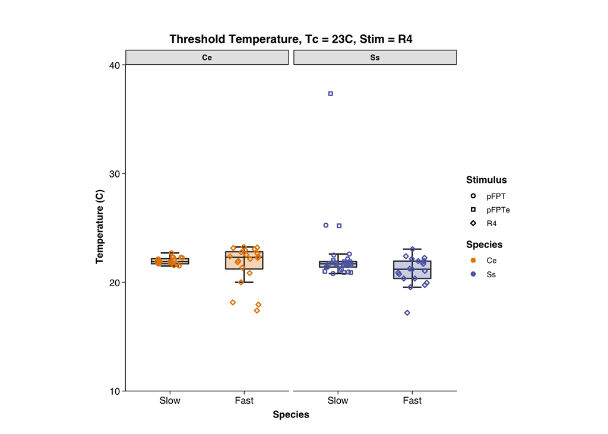

```r
p.thresh.across <- plot_AFD_type(dat_AFD_across,
                                 dat_AFD_across$Temperature,
                                 ylim,
                                 xlabel,
                                 ylabel,
                                 title)

print(p.thresh.across)
```

### 3.3.4 Tmax and Tmin responses

Plots showing the temperature that corresponds to the maximum and minimal calcium response for each trace. For now, just plotting Tc = 23.

#### 3.3.4.1 Max Response

```r
ylabel <- "Temperature (C)"
title <- "Temp @ Max Response, Tc = 23C, Stim = R4"
ylim <- c(15, 45)

stat.max.R4 <- compare_means(MaximalTemp ~ Species,
                             data = dat_AFD_R4,
                             alternative = "two.sided")
```

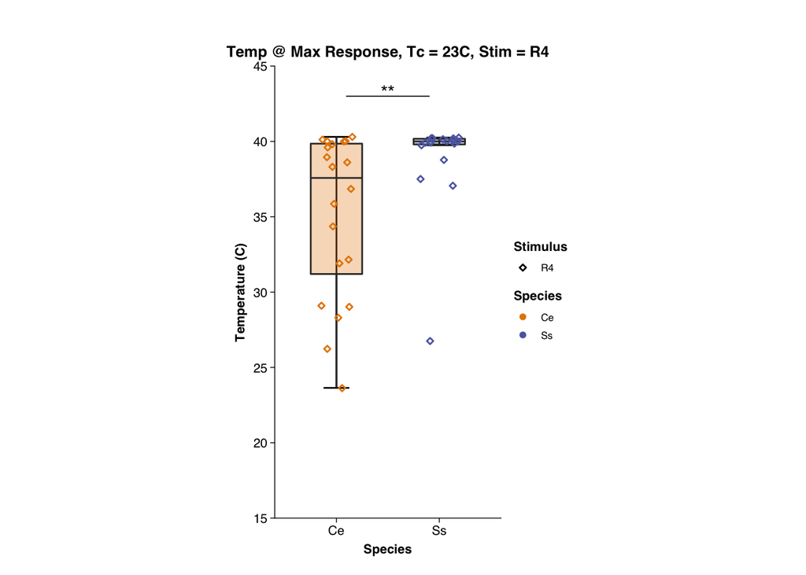

```r
p.max.R4 <- plot_AFD(dat_AFD_R4,
                     dat_AFD_R4$MaximalTemp,
                     ylim,
                     xlabel,
                     ylabel,
                     stat.max.R4,
                     43,
                     title)

print(p.max.R4)
```

#### 3.3.4.2 Min Response

```r
ylabel <- "Temperature (C)"
title <- "Temp @ Min Response, Tc = 23C"
ylim <- c(15, 45)

stat.min.R4 <- compare_means(MinimalTemperature ~ Species,
                             data = dat_AFD_R4,
                             alternative = "two.sided")
```

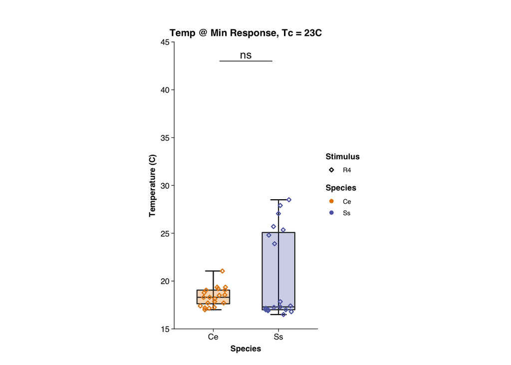

```r
p.min.R4 <- plot_AFD(dat_AFD_R4,
                     dat_AFD_R4$MinimalTemperature,
                     ylim,
                     xlabel,
                     ylabel,
                     stat.min.R4,
                     43,
                     title)

print(p.min.R4)
```

### 3.3.5 Is Tmin above T0?

```r
xlabel <- "Stimulus"
ylabel <- "Proportion of Worms"
title <- "Deviation of Calcium Trace from T0"

temp_dat <- dat_AFD_across %>%
  dplyr::mutate(Dir_Tmin = factor(case_when(
    TminAboveT0 > 0 ~ "Above",
    TminAboveT0 == 0 ~ "Below"),
    levels = c("Above", "Below"))) %>%
  group_by(Species,Tc, Type, Dir_Tmin)

# Counts of various conditions
dplyr::count(temp_dat, TminAboveT0)
```

| Species | Tc | Type | Dir_Tmin | TminAboveT0 | n |
| --- | --- | --- | --- | --- | --- |
| Ce | 23 | Slow | Below | 0 | 20 |
| Ce | 23 | Fast | Below | 0 | 20 |
| Ss | 23 | Slow | Above | 1 | 25 |
| Ss | 23 | Slow | Below | 0 | 5 |
| Ss | 23 | Fast | Above | 1 | 7 |
| Ss | 23 | Fast | Below | 0 | 12 |

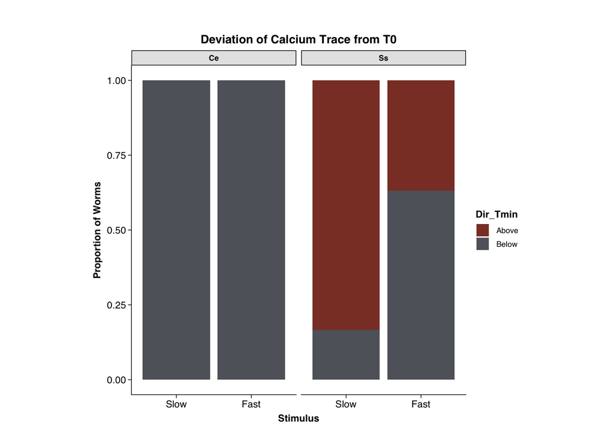

```r
p.bar.TminAboveT0 <- ggplot(data = temp_dat, mapping = aes(x = Type)) +
  geom_bar(aes(fill = Dir_Tmin), position = "fill") +
  scale_color_manual(values = c("Below" = "#5F6369",
                                "Above" = "coral4"),
                     aesthetics = c("colour", "fill")) +
  facet_grid(. ~ Species)+
  xlab(xlabel) +
  ylab(ylabel) +
  ggtitle(title) +
  theme_Publication() +
  theme(aspect.ratio = 2/1)

print(p.bar.TminAboveT0)
```

## 3.4 Negative Stimuli

Responses of *Ss*-AFD and *Ce*-AFD to negative thermal ramps based on those commonly used for *C. elegans* experiments (Colon-Ramos lab, in particular). In these cases, ramp speeds are generally -0.1C/s.

### 3.4.1 Pearson Correlation

Is the calcium response linearly correlated with changes in temperature. Correlation between calcium repsonses and temperature are analyzed across the following temperature ranges:

- For Tc = 23, from 13 - 22C (NT)

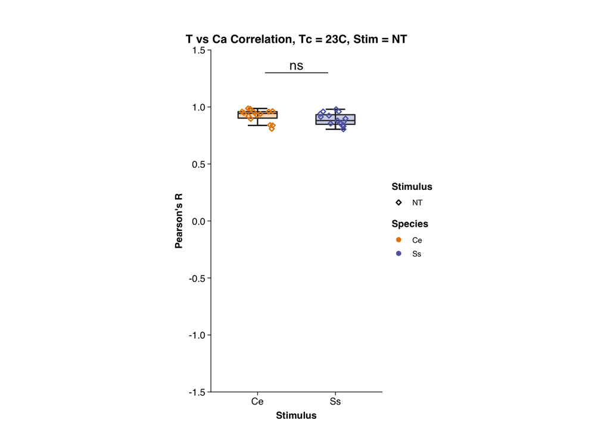

```r
dat_AFD_NT <- dat_AFD %>%
  dplyr::filter(Stimulus == "NT")

ylabel <- "Pearson's R"
title <- "T vs Ca Correlation, Tc = 23C, Stim = NT"
ylim <- c(-1.5, 1.5)
stat.pearson.NT <- compare_means(AboveThPearsonR ~ Species,
                                 data = dat_AFD_NT,
                                 alternative = "two.sided")

p.pearson.NT <- plot_AFD(dat_AFD_NT,
                         dat_AFD_NT$AboveThPearsonR,
                         ylim,
                         xlabel,
                         ylabel,
                         stat.pearson.NT,
                         1.3,
                         title)

print(p.pearson.NT)
```

### 3.4.2 Group and Save AFD Plots

```r
ggarrange(
  p.thresh.across,
  p.pearson.R4,
  p.bar.TminAboveT0,
  p.min.R4,
  p.max.R4,
  p.pearson.NT,
  ncol = 2,
  nrow = 3
) %>%
  ggsave(filename ="AFD_Plots_R4+NT.pdf",
         device = cairo_pdf,
         width = 7,
         height = 6.3,
         path = dirname(dat_AFD_file))
```

# 4 Reversal Behaviors

Worm tracking and calcium imaging data for reversal behaviors exhibited by *S. stercoralis* iL3s.

## 4.1 Data Inputs

These data were preprocessed and calculated by TCI Matlab code.

```r
dat_reversal_file <- c('~/Box Sync/Lab_Hallem/Astra/Writing/Bryant et al 20xx/Data/Reversal Behavior/Reversal_R_Import.xlsx')

if (is_empty(dat_reversal_file)){
  dat_reversal_file <- file.choose()
}
dat_reversal <- read_excel(dat_reversal_file, sheet = 1) %>%
  group_by(Gradient,Tc) %>%
  dplyr::mutate(Gradient = factor(Gradient, levels = c("High", "Low"))) %>%
  dplyr::mutate(Tc = factor(Tc, levels = c(23, 15)))
```

## 4.2 Plot Templates

```r
plot_reversal_Range <-  function(dat, y, ylim, xlabel, ylabel, title = NULL){
  ggplot(data = dat, mapping = aes(x = Tc, y = y)) +
    stat_boxplot(geom = "errorbar",
                 width = 0.25,
                 size = .5) +
    geom_boxplot(width = 0.5,
                 outlier.shape = NA,
                 fatten = 1,
                 key_glyph = "rect",
                 alpha = 0.3,
                 show.legend = F,
                 aes(fill = Tc)) +
    geom_jitter(size = 1,
                stroke = .75,
                width = .2,
                aes(color = Tc, shape = Gradient)) +
    facet_grid(. ~ Gradient)+
    scale_y_continuous(limits = ylim,
                       expand = expansion(add = 0)) +
    scale_color_carto_d(palette = "Vivid") +
    scale_fill_carto_d(palette = "Vivid") +
    scale_shape_manual(values = c(21:23))  +
    xlab(xlabel) +
    ylab(ylabel) +
    ggtitle(title) +
    theme_Publication() +
    theme(aspect.ratio = 2/1)
}
```

## 4.3 Percent Reversals

This plot shows the percent of positive thermotaxing worms that engage in reversal behaviors, for each condition.

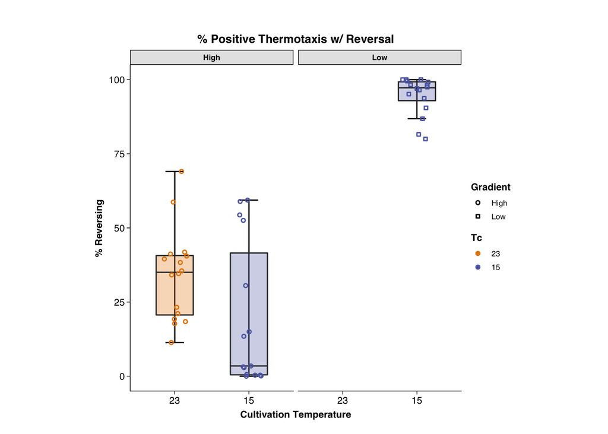

```r
p.reversals.PT <- plot_reversal_Range(dat_reversal,
                                      dat_reversal$Percent_PT_Reversing,
                                      ylim = c(-5, 105),
                                      xlabel = "Cultivation Temperature",
                                      ylabel = "% Reversing",
                                      title = "% Positive Thermotaxis w/ Reversal")

print(p.reversals.PT)
```

This plot shows the percent of all worms that engage in reversal behaviors, for each condition.

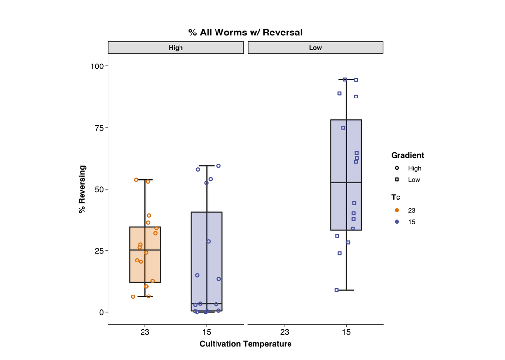

```r
p.reversals.All <- plot_reversal_Range(dat_reversal,
                                       dat_reversal$Percent_All_Reversing,
                                       ylim = c(-5, 105),
                                       xlabel = "Cultivation Temperature",
                                       ylabel = "% Reversing",
                                       title = "% All Worms w/ Reversal")

print(p.reversals.All)
```

# 5 AFD Adaptation

## 5.1 Data Inputs

```r
dat_adapt_file <- c('~/Box Sync/Lab_Hallem/Astra/Writing/Bryant et al 20xx/Data/Calcium Imaging/Adaptation_R_Import.xlsx')

if (is_empty(dat_adapt_file)){
  dat_adapt_file <- file.choose()
}
dat_AFD_adaptation <- read_excel(dat_adapt_file, sheet = 1) %>%
  dplyr::mutate(Species = as_factor(Species)) %>%
  dplyr::mutate(Stimulus = factor(Stimulus, levels = c("Reversal", "pFPT", "pFPTe", "NT"))) %>%
  dplyr::mutate(Tc = factor(Tc, levels = c(23, 15))) %>%
  dplyr::mutate(UID = as_factor(UID)) %>%
  pivot_longer(cols = c(AdaptWindowEarly, AdaptWindowLate),
               names_to = "Bin",
               names_prefix = "AdaptWindow",
               values_to = "CaResponse") %>%
  dplyr::mutate(Bin = factor(Bin, levels = c("Early", "Late"))) %>%
  dplyr::mutate(Dir_late = factor(case_when(
    AdaptWindowLate_Cat > 0 ~ "Sig Diff",
    AdaptWindowLate_Cat < 0 ~ "Sig Diff",
    AdaptWindowLate_Cat == 0 ~ "Not Sig"),
    levels = c("Sig Diff", "Not Sig"))) %>%
  dplyr::mutate(Dir_early = factor(case_when(
    AdaptWindowEarly_Cat > 0 ~ "Sig Diff",
    AdaptWindowEarly_Cat < 0 ~ "Sig Diff",
    AdaptWindowEarly_Cat == 0 ~ "Not Sig"),
    levels = c("Sig Diff", "Not Sig"))) %>%
  group_by(Species,Tc, Stimulus, UID)
```

## 5.2 Tmax

This should reveal any adaptation in the response once temperature is holding at Tmax (for variable lengths of time).

### 5.2.1 Calcium Response Across T(max)

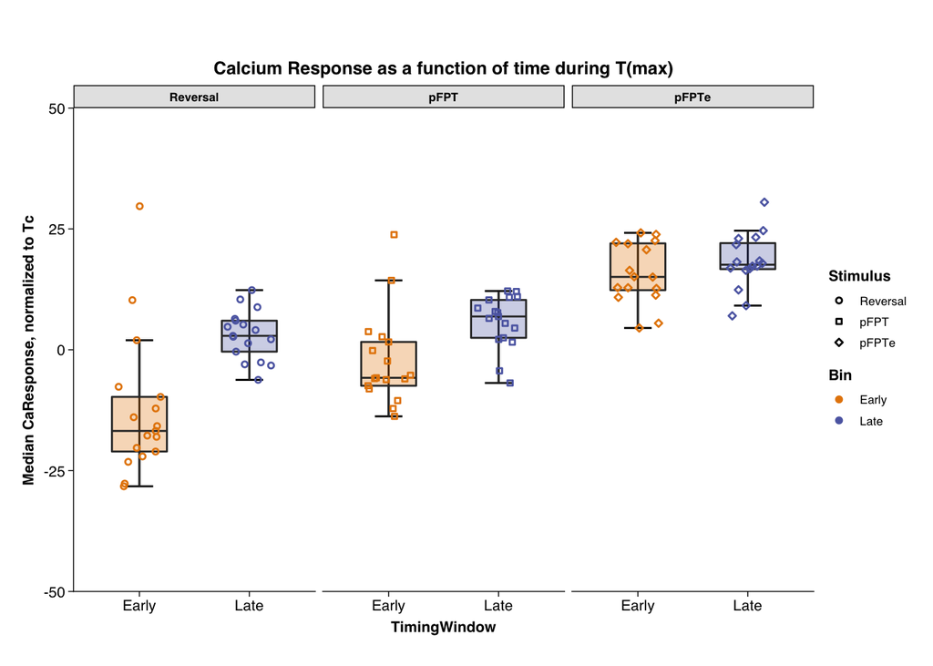

```r
xlabel <- "TimingWindow"
ylabel <- "Median CaResponse, normalized to Tc"
title <- "Calcium Response as a function of time during T(max)"
ylim <- c(-50, 50)

p.Tmax.adapt <- dat_AFD_adaptation %>%
  dplyr::filter(Stimulus != "NT" & Species != "Ce") %>%
  ggplot(mapping = aes(x = Bin, y = CaResponse)) +
  stat_boxplot(geom = "errorbar",
               width = 0.25,
               size = .5) +
  geom_boxplot(width = 0.5,
               outlier.shape = NA,
               fatten = 1,
               key_glyph = "rect",
               alpha = 0.3,
               show.legend = F,
               aes(fill = Bin)) +
  geom_jitter(size = 1,
              stroke = .75,
              width = .2,
              aes(color = Bin, shape = Stimulus)) +
  facet_grid(. ~ Stimulus)+
  scale_y_continuous(limits = ylim,
                     expand = expansion(add = 0)) +
  scale_color_carto_d(palette = "Vivid") +
  scale_fill_carto_d(palette = "Vivid") +
  scale_shape_manual(values = c(21:23))  +
  xlab(xlabel) +
  ylab(ylabel) +
  ggtitle(title) +
  theme_Publication() +
  theme(aspect.ratio = 2/1)

print(p.Tmax.adapt)
```

### 5.2.2 Calcium Response Ss vs Ce at T(max)

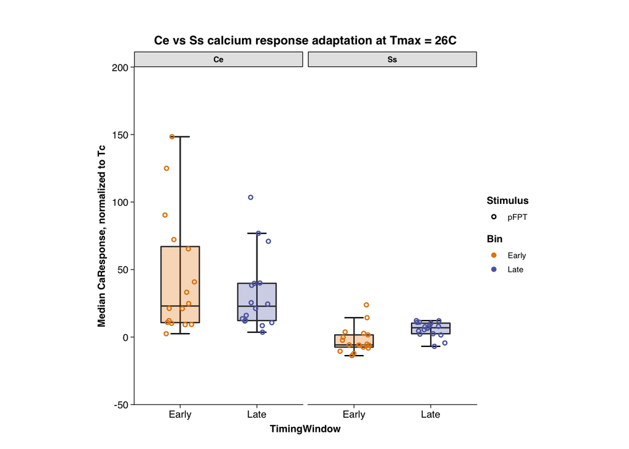

```r
xlabel <- "TimingWindow"
ylabel <- "Median CaResponse, normalized to Tc"
title <- "Ce vs Ss calcium response adaptation at Tmax = 26C"
ylim <- c(-50, 200)

p.Tmax.adapt_species <- dat_AFD_adaptation %>%
  dplyr::filter(Stimulus == "pFPT") %>%
  dplyr::mutate(Species = relevel(Species, "Ce")) %>%
  ggplot(mapping = aes(x = Bin, y = CaResponse)) +
  stat_boxplot(geom = "errorbar",
               width = 0.25,
               size = .5) +
  geom_boxplot(width = 0.5,
               outlier.shape = NA,
               fatten = 1,
               key_glyph = "rect",
               alpha = 0.3,
               show.legend = F,
               aes(fill = Bin)) +
  geom_jitter(size = 1,
              stroke = .75,
              width = .2,
              aes(color = Bin, shape = Stimulus)) +
  facet_grid(. ~ Species)+
  scale_y_continuous(limits = ylim,
                     expand = expansion(add = 0)) +
  scale_color_carto_d(palette = "Vivid") +
  scale_fill_carto_d(palette = "Vivid") +
  scale_shape_manual(values = c(21:23))  +
  xlab(xlabel) +
  ylab(ylabel) +
  ggtitle(title) +
  theme_Publication() +
  theme(aspect.ratio = 2/1)

print(p.Tmax.adapt_species)
```

### 5.2.3 Categorical

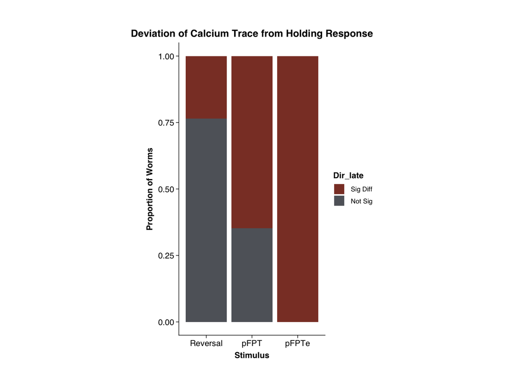

```r
xlabel <- "Stimulus"
ylabel <- "Proportion of Worms"
title <- "Deviation of Calcium Trace from Holding Response"


p.bar.adapt.late <- dat_AFD_adaptation %>%
  dplyr::filter(Stimulus != "NT") %>%
  dplyr::filter(Species != "Ce") %>%
  ggplot(mapping = aes(x = Stimulus)) +
  geom_bar(aes(fill = Dir_late), position = "fill") +
  scale_color_manual(values = c("Not Sig" = "#5F6369",
                                "Sig Diff" = "coral4"),
                     aesthetics = c("colour", "fill")) +
  xlab(xlabel) +
  ylab(ylabel) +
  ggtitle(title) +
  theme_Publication() +
  theme(aspect.ratio = 2/1)

print(p.bar.adapt.late)
```

## 5.3 Tmin

This should reveal any adaptation in the response once temperature is holding at Tmin (for variable lengths of time). This is for thermal stimuli approximating negative thermotaxis

### 5.3.1 Calcium Response

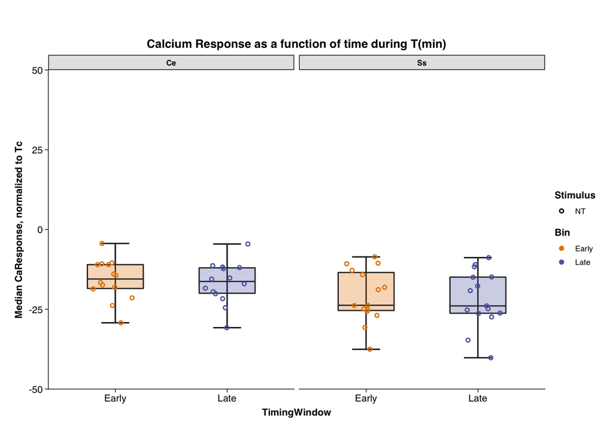

```r
xlabel <- "TimingWindow"
ylabel <- "Median CaResponse, normalized to Tc"
title <- "Calcium Response as a function of time during T(min)"
ylim <- c(-50, 50)

p.Tmin.adapt <- dat_AFD_adaptation %>%
  dplyr::filter(Stimulus == "NT") %>%
  dplyr::mutate(Species = relevel(Species, "Ce")) %>%
  ggplot(mapping = aes(x = Bin, y = CaResponse)) +
  stat_boxplot(geom = "errorbar",
               width = 0.25,
               size = .5) +
  geom_boxplot(width = 0.5,
               outlier.shape = NA,
               fatten = 1,
               key_glyph = "rect",
               alpha = 0.3,
               show.legend = F,
               aes(fill = Bin)) +
  geom_jitter(size = 1,
              stroke = .75,
              width = .2,
              aes(color = Bin, shape = Stimulus)) +
  facet_grid(. ~ Species)+
  scale_y_continuous(limits = ylim,
                     expand = expansion(add = 0)) +
  scale_color_carto_d(palette = "Vivid") +
  scale_fill_carto_d(palette = "Vivid") +
  scale_shape_manual(values = c(21:23))  +
  xlab(xlabel) +
  ylab(ylabel) +
  ggtitle(title) +
  theme_Publication() +
  theme(aspect.ratio = 1.3/1)

print(p.Tmin.adapt)
```

Run a Mann-Whitney test of Ss-AFD (Tc = 23C) at 13C (early window) versus Ss-AFD (Tc = 23C) at 13C (late window).

```r
temp <-  dplyr::filter(dat_AFD_adaptation, Stimulus == "NT" & Species == "Ss")
compare_means(CaResponse ~ Bin,
              data = temp)
```

| .y. | group1 | group2 | p | p.adj | p.format | p.signif | method |
| --- | --- | --- | --- | --- | --- | --- | --- |
| CaResponse | Early | Late | 0.65287 | 0.65 | 0.65 | ns | Wilcoxon |

Compare responses of Ss-AFD (Tc = 23C) at 13C (early window) versus Ss-AFD (Tc = 15C) at 22C (early window). This is asking if there warming-mediated hyperpolarization and cooling-mediated hyperpolarizations are the same initial magnitude, with only the warming-mediated hyperpolarization showing rapid adaptation.

```r
temp <-  dplyr::filter(dat_AFD_adaptation, Stimulus == "NT" & Species == "Ss" & Bin == "Early") %>%
  dplyr::ungroup() %>%
  dplyr::select(Stimulus,CaResponse)

temp <- dplyr::filter(dat_AFD_adaptation, Stimulus == "Reversal" & Species == "Ss" & Bin == "Early") %>%
  dplyr::ungroup() %>%
  dplyr::select(Stimulus,CaResponse) %>%
  dplyr::bind_rows(temp) %>%
  dplyr::group_by(Stimulus)

compare_means(CaResponse ~ Stimulus,
              data = temp)
```

| .y. | group1 | group2 | p | p.adj | p.format | p.signif | method |
| --- | --- | --- | --- | --- | --- | --- | --- |
| CaResponse | Reversal | NT | 0.08943298 | 0.089 | 0.089 | ns | Wilcoxon |

Compare responses of Ss-AFD (Tc = 23C) at 13C (late window) versus Ss-AFD (Tc = 15C) at 22C (late window). This is asking if there warming-mediated hyperpolarization and cooling-mediated hyperpolarizations are the same “adapted” magnitude. The better way to do this would be a 2-way ANoVA

```r
temp <-  dplyr::filter(dat_AFD_adaptation, Stimulus == "NT" & Species == "Ss") %>%
  dplyr::ungroup() %>%
  dplyr::select(Stimulus,CaResponse, Bin)

temp <- dplyr::filter(dat_AFD_adaptation, Stimulus == "Reversal" & Species == "Ss") %>%
  dplyr::ungroup() %>%
  dplyr::select(Stimulus,CaResponse, Bin) %>%
  dplyr::bind_rows(temp)


options(contrasts = c("contr.sum", "contr.poly"))
res.aov2<- aov(CaResponse ~ Bin * Stimulus, data = temp)
Anova(res.aov2, type = "III")
```

|  | Sum Sq | Df | F value | Pr(>F) |
| --- | --- | --- | --- | --- |
| (Intercept) | 10800.7502 | 1 | 109.221720 | 3.919347e-15 |
| Bin | 843.4534 | 1 | 8.529354 | 4.917277e-03 |
| Stimulus | 4377.2549 | 1 | 44.264639 | 9.738267e-09 |
| Bin:Stimulus | 1086.5161 | 1 | 10.987307 | 1.559596e-03 |
| Residuals | 5933.2980 | 60 | NA | NA |

```r
res.aov3<-TukeyHSD(res.aov2, "Bin:Stimulus")
as_tibble(res.aov3$`Bin:Stimulus`, rownames = "comparison") %>%
  separate(col = comparison, into = c("comp1", "LS1", "comp2", "LS2")) %>%
  dplyr::filter(comp1 == comp2) %>%
  unite(temp1, comp1, LS1, sep = ":")%>%
  unite(temp2, comp2, LS2, sep = ":")%>%
  unite(comparison, temp1, temp2, sep = "-")
```

| comparison | diff | lwr | upr | p adj |
| --- | --- | --- | --- | --- |
| Early:NT-Early:Reversal | -8.315878 | -17.62472 | 0.9929671 | 9.598042e-02 |
| Late:NT-Late:Reversal | -24.829335 | -34.13818 | -15.5204891 | 1.235907e-08 |

## 5.4 Group and Save Plots

```r
ggarrange(
  p.reversals.PT,
  p.reversals.All,
  p.bar.adapt.late,
  p.Tmax.adapt,
  p.Tmax.adapt_species,
  p.Tmin.adapt,
  ncol = 2,
  nrow = 4
) %>%
  ggsave(filename ="Reversal+Adaptation_Plots.pdf",
         #plot = p.reversals,
         device = cairo_pdf,
         width = 7,
         height = 8.4,
         path = dirname(dat_adapt_file))
```

# 6 Ss-AFD-rGC Ecoptic Expression Analysis

Analysis and plotting for a series of experiments testing the effect of misepxresion of *Ss-gcy-23.1*, *Ss-gcy-23.2*, and *Ss-gcy-23.3* in *C. elegans* ASE neurons, in response to the pseudo-fictive PTe 20-40$^\circ$C ramp.

## 6.1 Data Inputs

Data are preprocessed using Matlab TCI file `TCI_analyzeEctopic.m`, which calculates the temperature at which point an experimental trace rises above 3*rms of mean control trace for at least 6 seconds.

This calculation is run independently for each trace, and the value (in degrees C) is saved.

```r
dat_ectopic_file <- c('~/Box Sync/Lab_Hallem/Astra/Writing/Bryant et al 20xx/Data/Calcium Imaging/Ectopic Expression/EctopicExpression_R_Import.xlsx')
#dat_file <- NULL
if (is_empty(dat_ectopic_file)){
  dat_ectopic_file <- file.choose()
}
meta_ectopic <-read_excel(dat_ectopic_file, sheet = "Metadata")
dat_ectopic <- read_excel(dat_ectopic_file, sheet = 1) %>%
  group_by(rGC,Strain)


dat_ectopic_filtered <- dat_ectopic %>%
  dplyr::filter(rGC != "ASE_ctrl") %>%
  dplyr::filter(!is.na(Thresh_temp)) %>%
  dplyr::bind_rows(dplyr::filter(dat_ectopic, rGC == "ASE_ctrl"))


dat_rGC_expression_file <- c('~/Box Sync/Lab_Hallem/Astra/Writing/Bryant et al 20xx/Data/Calcium Imaging/Ectopic Expression/SsAFDrGC_Gene_Expression_Data.xlsx')

if (is_empty(dat_rGC_expression_file)){
  dat_rGC_expression_file <- file.choose()
}
dat_rGC_expression <- read_excel(dat_rGC_expression_file,
                                 sheet = 1,
                                 skip = 5) %>%
  dplyr::select(geneID:UniProtKB) %>%
  dplyr::select(-UniProtKB) %>%
  pivot_longer(cols = -geneID,
               names_to = c("life_stage", "sample"),
               names_sep = "-",
               values_to = "log2CPM") %>%
  dplyr::mutate(life_stage = factor(life_stage,
                                    levels = c("PF",
                                               "FLF",
                                               "iL3",
                                               "iL3a",
                                               "ppL1",
                                               "ppL3",
                                               "pfL1"))) %>%
  dplyr::group_by(geneID, life_stage)
```

## 6.2 rGC Plot Templates

```r
source("theme_Publication.R")

plot_ectopic_noctrl <- function(dat, y, meta, ylim, xlabel,
                                ylabel, stat.test,
                                stat.y.position,
                                title = NULL){
  ggplot(data = dat, mapping = aes(x = rGC, y = y)) +

    stat_boxplot(geom = "errorbar",
                 width = 0.25,
                 size = 0.5) +
    geom_boxplot(width = 0.5,
                 outlier.shape = NA,
                 fatten = 1,
                 key_glyph = "rect",
                 alpha = 0.3,
                 aes(fill = rGC)) +
    geom_jitter(size = 2,
                stroke = .75,
                width = .2,
                aes(color = Strain, shape = Strain)) +
    stat_pvalue_manual(stat.test,
                       y.position = stat.y.position,
                       step.increase = 0.1,
                       tip.length = 0,
                       hide.ns = TRUE,
                       bracket.shorten = 0.2,
                       label = "p.adj.signif"
    ) +
    scale_y_continuous(limits = ylim,
                       expand = expansion(add = 0)) +
    xlab(xlabel) +
    ylab(ylabel) +
    ggtitle(title) +
    scale_fill_manual(values = c("darkorchid4", "cyan4", "coral4"))+
    #scale_color_carto_d(palette = "Bold") +
    scale_color_manual(values = c(rep(c("darkorchid4","cyan4", "coral4"),each = 3)))+
    scale_shape_manual(values = rep(c(21:23), 3))  +
    theme_Publication() +
    theme(aspect.ratio = 4/3,
          axis.text.x = element_text(angle= 45,

                                     hjust = 1))
}
```

## 6.3 Temperature Threshold

Stats are Kruskal-Wallis Test with Dunn’s Post tests for difference in response amplitude.

```r
# ---- Temperature Threshold Plot ----

xlabel <- "Ss-AFD-rGCs"
ylabel <- " Temperature (C)"
title <- "Threshold Temperature"
ylim <- c(19, 45)

dat.subset <-dplyr::filter(dat_ectopic_filtered, rGC != "ASE_ctrl")%>%
  dplyr::mutate(Strain = as_factor(Strain)) %>%
  dplyr::mutate(rGC = as_factor(rGC))

# Kruskal-Wallis testing of response amplitude differenec
one.way <- kruskal.test(Thresh_temp ~ rGC,
                        data = dat.subset)

# Posthoc Dunn tests with Bonferroni adjustment
post.hoc <- dunn.test::dunn.test(dat.subset$Thresh_temp,
                                 dat.subset$rGC,
                                 method = "bonferroni",
                                 table = FALSE,
                                 list = TRUE)
```

```
##   Kruskal-Wallis rank sum test
##
## data: x and group
## Kruskal-Wallis chi-squared = 20.9216, df = 2, p-value = 0
##
##
##                            Comparison of x by group
##                                  (Bonferroni)
##
## List of pairwise comparisons: Z statistic (adjusted p-value)
## -------------------------------------------------------
## SSTP_0000354300 - SSTP_0000775800 :  2.900435 (0.0056)*
## SSTP_0000354300 - SSTP_0000846800 : -1.454430 (0.2187)
## SSTP_0000775800 - SSTP_0000846800 : -4.492727 (0.0000)*
##
## alpha = 0.05
## Reject Ho if p <= alpha/2
```

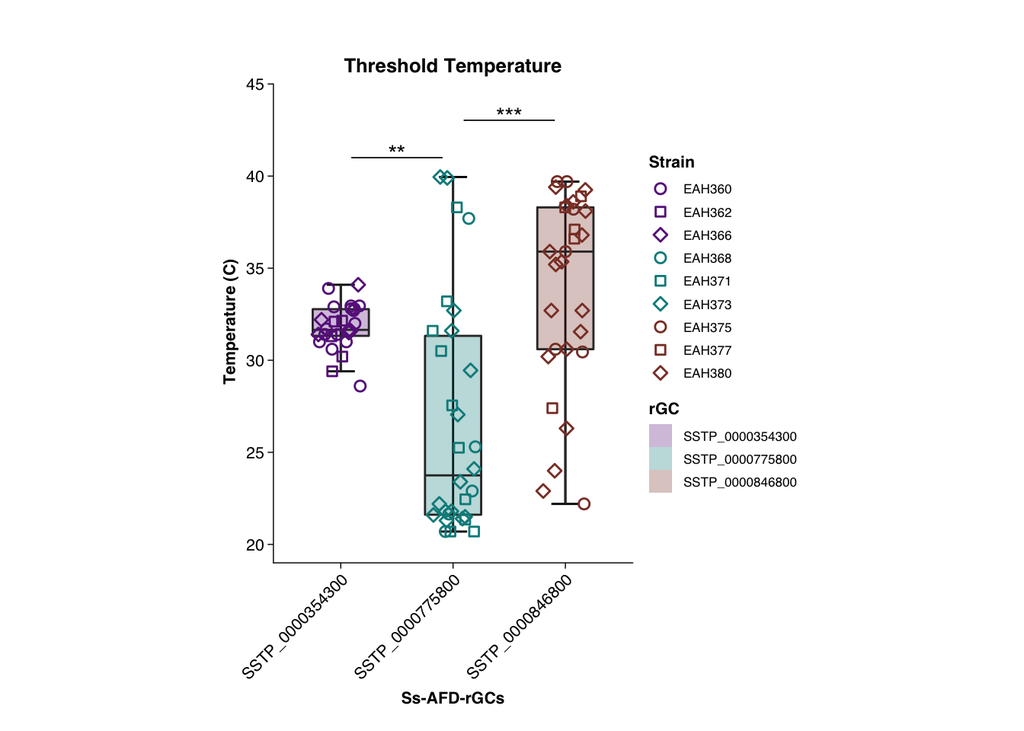

```r
stat.test.ectopic.thresh <- dplyr::tibble(
  comparisons = post.hoc$comparisons,
  p.adj = post.hoc$P.adjusted,
  p.adj.signif = stars.pval(post.hoc$P.adjusted)
) %>%
  mutate(p.adj.signif = case_when(p.adj.signif == " " ~ "ns",
                                  TRUE ~ as.character(p.adj.signif))) %>%
  tidyr::separate(comparisons,
                  into = c("group1", "group2"),
                  sep = " - ")

p_ectopic_thresh<- plot_ectopic_noctrl(dat.subset,
                                       dat.subset$Thresh_temp,
                                       meta_ectopic,
                                       ylim,
                                       xlabel,
                                       ylabel,
                                       stat.test.ectopic.thresh,
                                       41,
                                       title)


print(p_ectopic_thresh)
```

## 6.4 Temperature driving maximum response

Stats are Kruskal-Wallis Test with Dunn’s Post tests for difference in response amplitude.

```r
# Kruskal-Wallis testing of response amplitude differenec
one.way <- kruskal.test(Tmax ~ rGC,
                        data = dat.subset)

# Posthoc Dunn tests with Bonferroni adjustment
post.hoc <- dunn.test::dunn.test(dat.subset$Tmax,
                                 dat.subset$rGC,
                                 method = "bonferroni",
                                 table = FALSE,
                                 list = TRUE)
```

```
##   Kruskal-Wallis rank sum test
##
## data: x and group
## Kruskal-Wallis chi-squared = 18.1955, df = 2, p-value = 0
##
##
##                            Comparison of x by group
##                                  (Bonferroni)
##
## List of pairwise comparisons: Z statistic (adjusted p-value)
## -------------------------------------------------------
## SSTP_0000354300 - SSTP_0000775800 : -0.875094 (0.5723)
## SSTP_0000354300 - SSTP_0000846800 : -4.001531 (0.0001)*
## SSTP_0000775800 - SSTP_0000846800 : -3.249671 (0.0017)*
##
## alpha = 0.05
## Reject Ho if p <= alpha/2
```

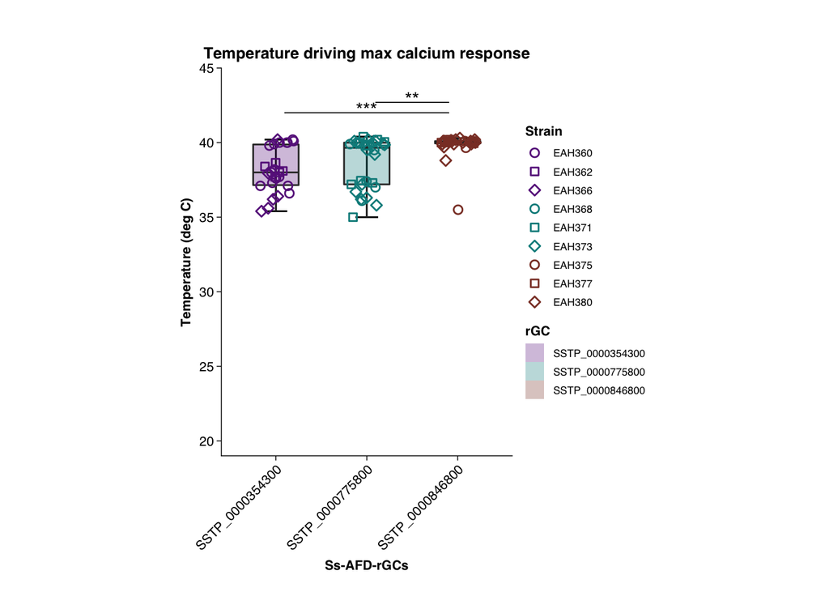

```r
xlabel <- "Ss-AFD-rGCs"
ylabel <- "Temperature (deg C)"
title <- "Temperature driving max calcium response"
ylim <- c(19,45)

stat.test.ectopic.Tmax <- dplyr::tibble(
  comparisons = post.hoc$comparisons,
  p.adj = post.hoc$P.adjusted,
  p.adj.signif = stars.pval(post.hoc$P.adjusted)
) %>%
  mutate(p.adj.signif = case_when(p.adj.signif == " " ~ "ns",
                                  TRUE ~ as.character(p.adj.signif))) %>%
  tidyr::separate(comparisons,
                  into = c("group1", "group2"),
                  sep = " - ")

p_Tmax<- plot_ectopic_noctrl(dat.subset,
                             dat.subset$Tmax,
                             meta_ectopic,
                             ylim,
                             xlabel,
                             ylabel,
                             stat.test.ectopic.Tmax,
                             42,
                             title)

print(p_Tmax)
```

## 6.5 Ss-AFD-rGC expression

Plot of RNA-seq expression levels across life stages for *Ss*-GCY-23.1, *Ss*-GCY-23.2, and *Ss*-GCY-23.3.

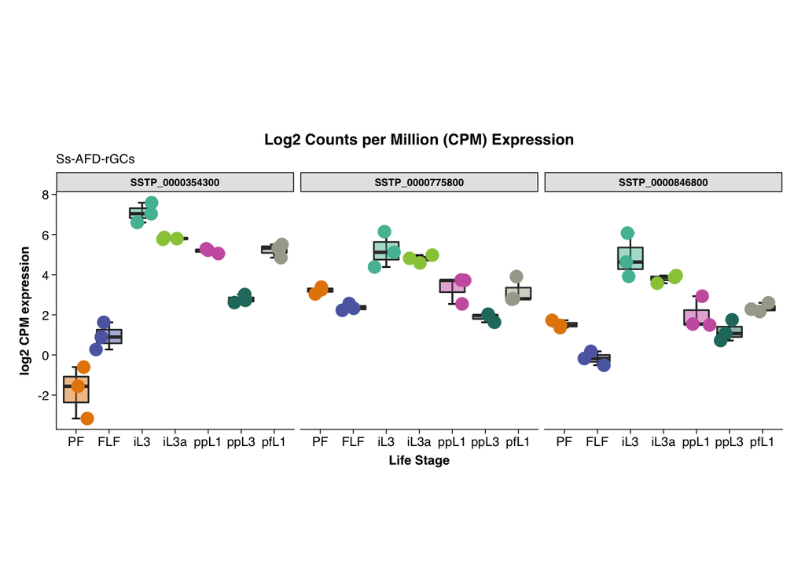

```r
ggplot(dat_rGC_expression) +
  aes(x = life_stage, y = log2CPM,
      fill = life_stage) +
  stat_boxplot(geom = "errorbar",
               width = 0.25,
               size = .5,
               show.legend = F) +
  geom_boxplot(show.legend = F,
               alpha = 0.5) +
  geom_jitter(size = 3,
              stroke = .75,
              show.legend = F,
              aes(color = life_stage)) +
  scale_fill_carto_d(palette = "Vivid") +
  scale_color_carto_d(palette = "Vivid") +
  facet_grid(. ~ geneID) +
  labs(y="log2 CPM expression", x = "Life Stage",
       title= "Log2 Counts per Million (CPM) Expression",
       subtitle= "Ss-AFD-rGCs") +
  theme_Publication() +
  theme(aspect.ratio=1)
```

```r
ggsave(filename ="rGC_expression.pdf",
         device = cairo_pdf,
         width = 7,
         # height = 3.5,
         path = dirname(dat_AFD_file))
```

## 6.6 Group and Save Ectopic Plots

```r
ggarrange(
  p_ectopic_thresh,
  p_Tmax,
  ncol = 2,
  nrow = 1
) %>%
  ggsave(filename ="rGC_Plots.pdf",
         device = cairo_pdf,
         width = 7,
         # height = 3.5,
         path = dirname(dat_AFD_file))
```